# Climatic Potential for Agricultural Productivity

Nick Gauthier

Last run on 2022-03-23

```
## Spherical geometry (s2) switched off
```

# Global productivity estimates

The Miami model of Helmut Lieth characterizes climatic potential net primary production (NPP) as a function of two limiting factors: mean annual temperature and total annual precipitation. It uses the following empirical functions to relate each variable to potential NPP, the lowest of which (i.e. the limiting factor) is taken as the final NPP estimate:

$$NPP_{precip} = 3000(1 - e^{-0.000664 P})$$
$$NPP_{temp} = \frac{3000}{1 + e^{1.315-0.119T}}$$

We'll apply this model to 30-year temperature and precipitation averages from the CHELSA dataset, a set of statistically downscaled climate data that corrects for topoclimatic influences like orographic precipitation and temperature inversions.In order to run this code, you will need to download the large CHELSA dataset files "CHELSA_bio10_01.tif" and "CHELSA_bio10_12.tif" from the CHELSA server:

[figure not shown]

```r
npp <- read_stars(c('CHELSA_bio10_01.tif', 'CHELSA_bio10_12.tif')) %>%
  setNames(c('temperature', 'precipitation')) %>%
  mutate(temperature = temperature / 10, # temperature is in degrees C * 10
         ### the miami model
         npp_prec = 3000 * (1 - exp(-0.000664 * precipitation)),
         npp_temp = 3000 / (1 + exp(1.315 - 0.119 * temperature)),
         npp = pmin(npp_prec, npp_temp)) %>%
  select(npp)
```

The resulting map gives us climatic potential NPP in grams of dry matter per square meter per year, with a theoretical maximum value of 3,000 $g/m^2$. This can be easily converted to expected crop yields using empirical coefficients for different crop types.

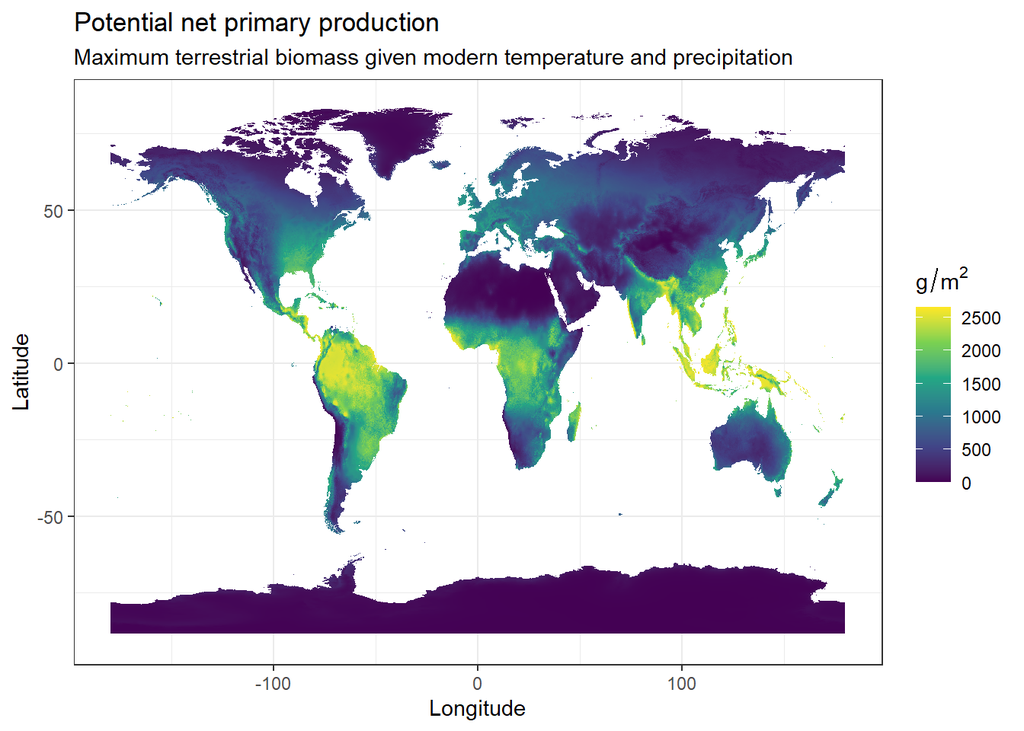

# Regional productivity estimates

## Southeast Mounds

Next clip the global NPP map to our regions of interest. Use the state boundaries of Alabama, Georgia, Mississippi, and Tennessee to define this study region.

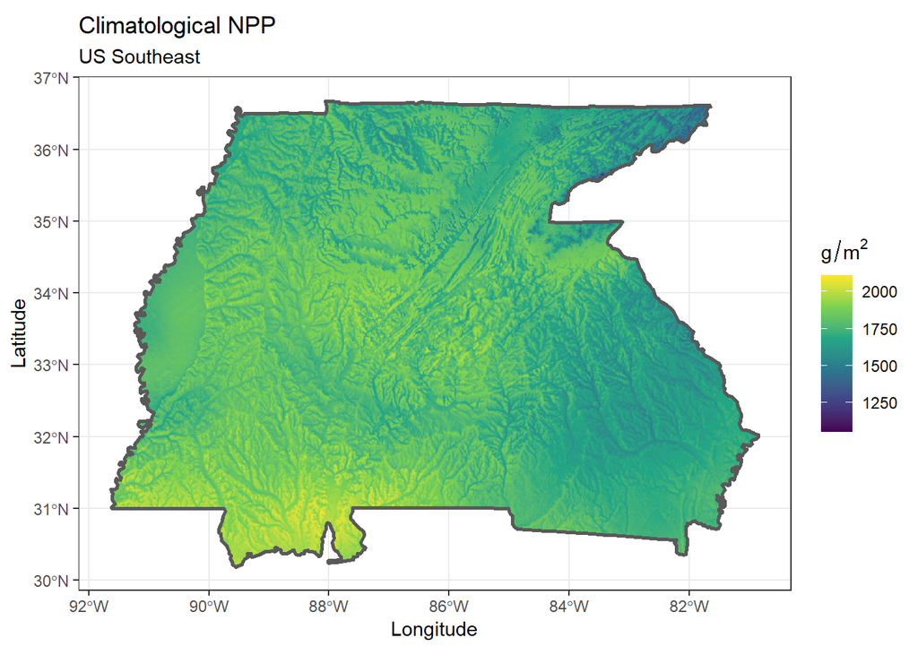

```r
# get state boundary shapefiles
se_boundary <- maps::map('state', regions = c('alabama', 'mississippi', 'georgia', 'tennessee'),
                    fill = TRUE, plot = FALSE) %>%
  st_as_sf() %>%
  st_union()

# subset global NPP and arable land
se_npp <- st_as_stars(npp[se_boundary])
```

## Southwest

Use the boundaries of Arizona, New Mexico, Colorado, and Utah

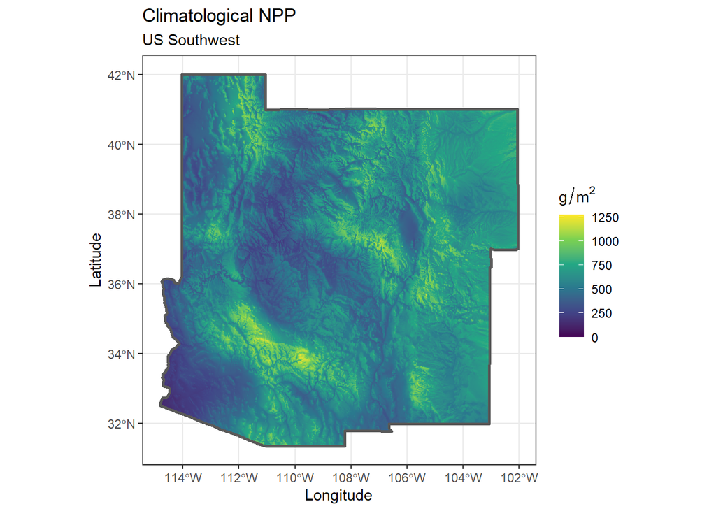

```r
# get state boundary shapefiles
sw_boundary <- maps::map('state', regions = c('arizona', 'new mexico', 'colorado', 'utah'),
                    fill = TRUE, plot = FALSE) %>%
  st_as_sf() %>%
  st_make_valid() %>%
  st_union()

sw_npp <- st_as_stars(npp[sw_boundary])
```

## Central Italy

Calculate a convex hull around all survey boundaries from Palmisano et al. 2018.

```r
rome <- read_sf('survey-boundaries/surveys.shp') %>%
  st_union() %>%
  st_convex_hull()

rome_npp <- st_as_stars(npp[rome])
```

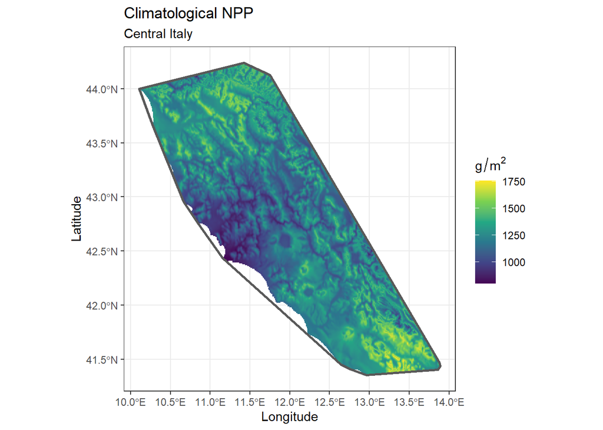

## Yautepec Valley Survey

Using the "valbordr" shapefile from the yv94-96 folder on Dropbox. Assuming the projection is the same as the Mixteca data.

```r
yautepec <- read_sf('survey-boundaries/valbordr.shp') %>%
  st_set_crs(26714) %>% # NAD27 UTM Zone 14N
  st_transform(4326) # transform to lat lon

yautepec_npp <- st_as_stars(npp[yautepec])
```

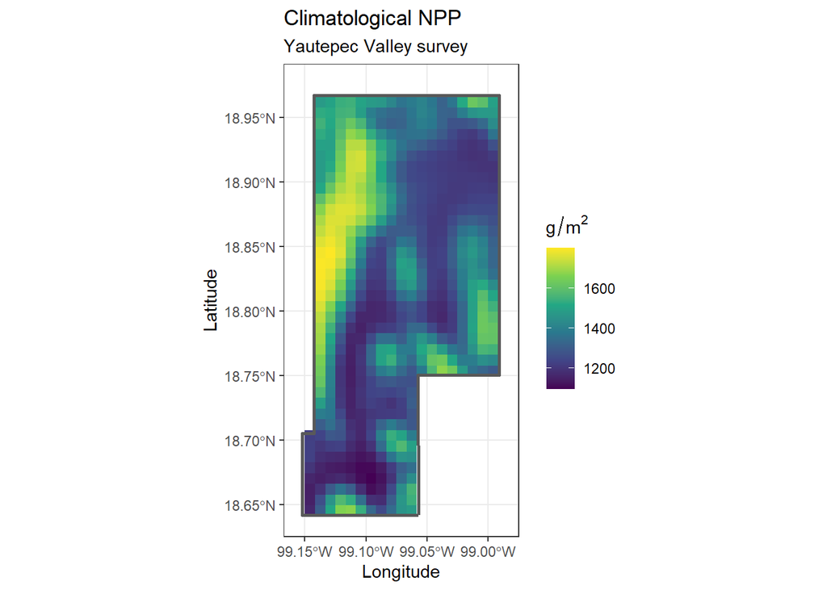

## Fertile Crescent

Load the Fragile Crescent project boundary shapefile.

```r
crescent <- read_sf('survey-boundaries/FertileCrescent_region.shp')

crescent_npp <- st_as_stars(npp[crescent])
```

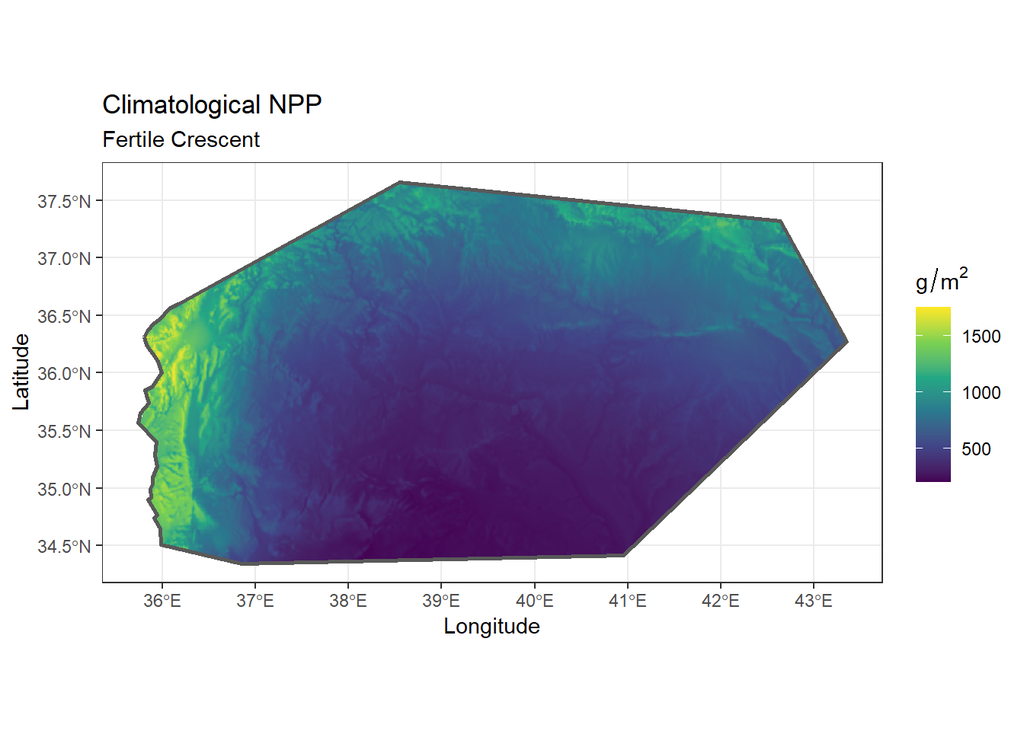

## Basin of Mexico

Read the Basin of Mexico hydrological boundary shapefile.

```r
bom <- read_sf('survey-boundaries/a2606.shp') %>%
  st_union() %>%
  st_transform(st_crs(npp))

bom_npp <- st_as_stars(npp[bom])
```

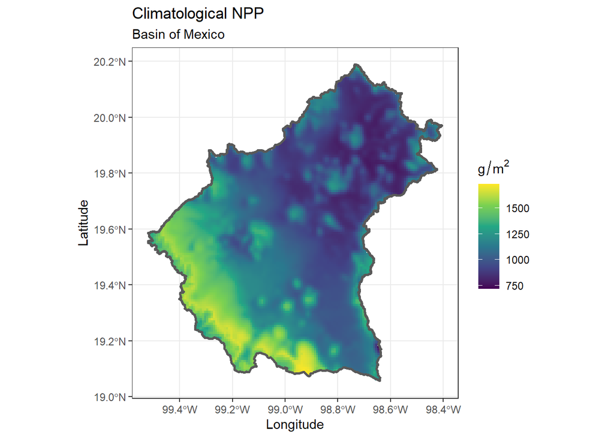

## Santa Valley

```r
santa <- read_sf('survey-boundaries/santa_valley.shp') %>%
  st_union() %>%
  st_transform(st_crs(npp))

santa_npp <- st_as_stars(npp[santa])
```

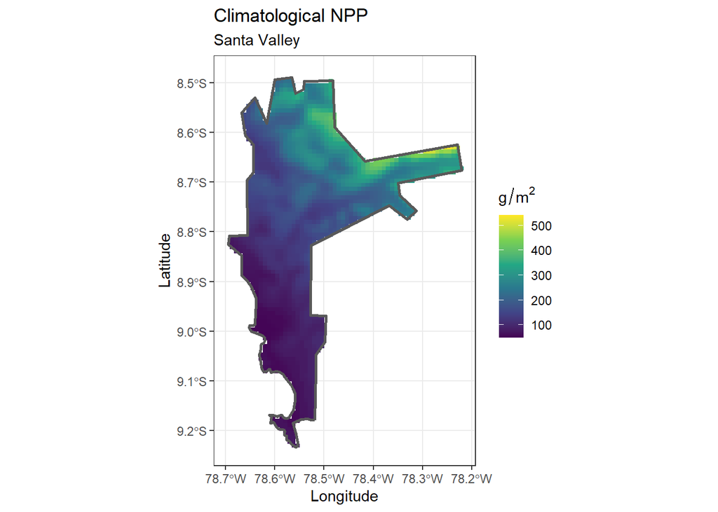

## Comparison

As the maps above highlight, NPP varies greatly across regions. How do their distributions look on the same scale?

```r
npp_dat <- list('Central Italy' = rome_npp, 'Southwest US' = sw_npp, 'Southeast US' = se_npp, 'Yautepec Valley' = yautepec_npp, 'Northern Fertile Crescent' = crescent_npp, 'Basin of Mexico' = bom_npp, 'Santa Valley' = santa_npp) %>%
  map_dfr(as_data_frame, .id = 'region') %>%
  select(-x, -y) %>%
  remove_missing()

write_csv(npp_dat, 'npp_dat.csv')
```

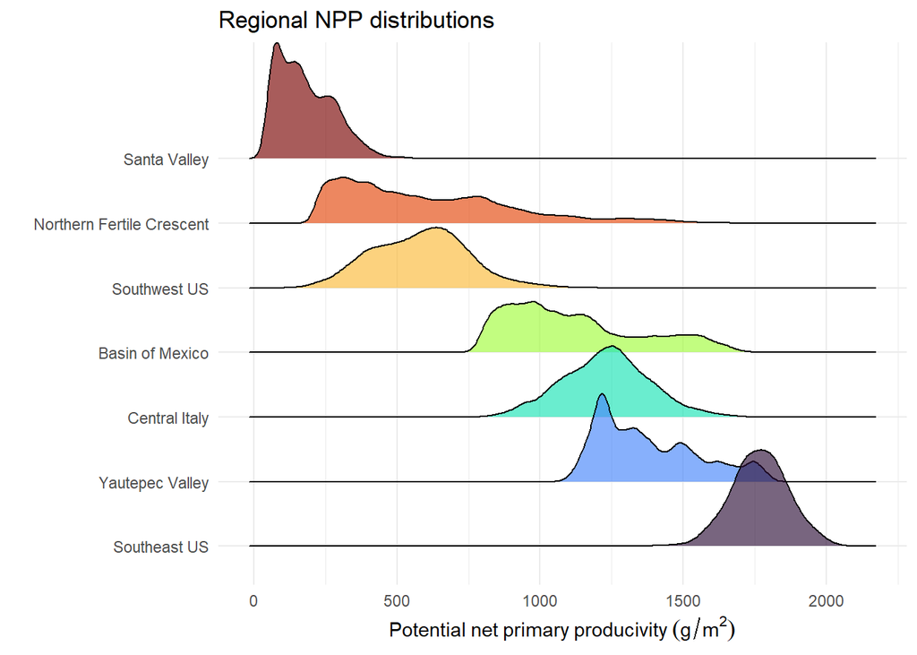

```r
npp_dat <- read_csv('npp_dat.csv')
ggplot(npp_dat, aes(npp,
                      reorder(region, -npp, FUN = median),
                      fill = reorder(region, npp, FUN = median))) +
  geom_density_ridges(alpha = .65) +
 scale_fill_viridis_d(option = 'turbo', name = 'Region', direction = -1) +
  ggtitle('Regional NPP distributions') +
  labs(y = '', x = expression(Potential~net~primary~producivity~(g/m^2))) +
  theme_minimal() +
  theme(legend.position = 'none')
```

```r
ggsave('npp_dist_turbo.png', height = 4, width = 6)
```

# Regional shapefiles plot

```r
# generate data for plotting
land <- rnaturalearth::ne_download(scale = 'small', type = 'land', category = 'physical', returnclass = 'sf')
bnds <- list('Central Italy' = st_zm(rome), 'Southwest US' = sw_boundary, 'Southeast US' = se_boundary, 'Yautepec Valley' = yautepec, 'Northern Fertile Crescent' = crescent, 'Basin of Mexico' = bom, 'Santa Valley' = santa)  %>%
  map(st_geometry) %>%
  do.call(c, .) %>%
  st_sf(row.names = c('Central Italy', 'Southwest US', 'Southeast US', 'Yautepec Valley', 'Northern Fertile Crescent', 'Basin of Mexico', 'Santa Valley')) %>%
  rownames_to_column() %>%
  mutate(rowname = factor(rowname, levels = c('Santa Valley', 'Northern Fertile Crescent', 'Southwest US','Basin of Mexico','Central Italy', 'Yautepec Valley',  'Southeast US') )) %>%
  arrange(rowname)
```

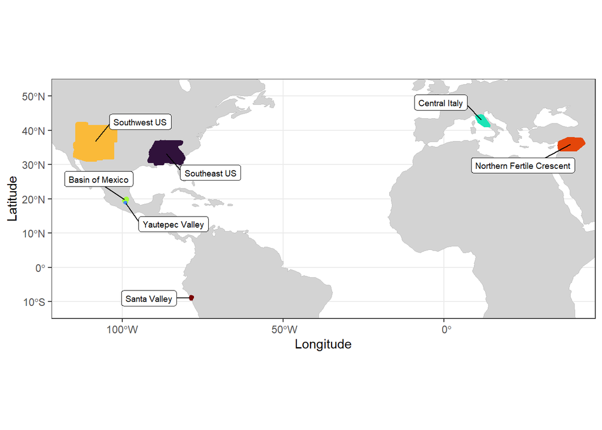

```r
ggplot(land) +
  geom_sf(fill = "lightgray", color = "gray", size = 0.5/.pt) +
  geom_sf(data = bnds, aes(fill = rowname, color = rowname), size = 1.5) +
  scale_fill_viridis_d(option = 'turbo', direction = -1) +
  scale_color_viridis_d(option = 'turbo', direction = -1) +
  geom_label_repel(data = bnds, aes(geometry = geometry, label = rowname), stat = 'sf_coordinates', min.segment.length = 0, box.padding = 0.75, size = 2.5) +
  labs(x = 'Longitude', y = 'Latitude') +
  coord_sf(xlim = c(-122, 47), ylim = c(-15, 55), expand = FALSE) +
  theme_bw() +
  theme(legend.position = 'none')
```

```r
ggsave('case_studies_v2.png', height = 3, width = 6.5)
```